# homework

Yifei Zhu

2023-12-08

# HW0

## Example 1 正弦函数和余弦函数图像

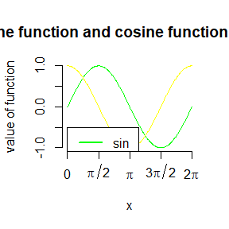

```r
x<-seq(0,2*pi,length=300)
plot(x,sin(x),type = 'l',col="green",
     main = "Sine function and cosine function image",
     ylab = "value of function",axes = FALSE)#正弦
lines(x,cos(x),col="yellow")#余弦
legend(0,-0.5,col =c("green","yellow"),
       lty = c(1,1),lwd=c(2,2),legend = c("sin","cos"))#图例
axis(2)#纵坐标
axis(1,at=(0:4)/2*pi,labels =
       c(0,expression(pi/2),expression(pi),
         expression(3*pi/2),expression(2*pi)))#横坐标
```

## Example 2 班级成绩

```r
set.seed(1234)
d1<-floor(runif(10,70,100))
d2<-floor(runif(10,70,100))
d3<-floor(runif(10,70,100))
score<-data.frame(1:10,d1,d2,d3,d1+d2+d3)
colnames(score)<-c("学号","语文","数学","英语","总分")
score
```

```
##    学号 语文 数学 英语 总分
## 1     1   73   90   79  242
## 2     2   88   86   79  253
## 3     3   88   78   74  240
## 4     4   88   97   71  256
## 5     5   95   78   76  249
## 6     6   89   95   94  278
## 7     7   70   78   85  233
## 8     8   76   78   97  251
## 9     9   89   75   94  258
## 10   10   85   76   71  232
```

## Example 3 汽车发动机排量与耗油量散点图

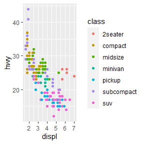

```r
library(ggplot2)
ggplot(data=mpg,aes(x=displ,y=hwy,color=class))+geom_point()
```

# HW1

## 第一题 3.4

由于$f(x)=\frac{x}{\sigma^2}e^{-x^2/(2\sigma^2)}$，因此分布函数
$$F(y)=\int_0^y\frac{x}{\sigma^2}e^{-x^2/(2\sigma^2)}dx=\int_0^ye^{-x^2/(2\sigma^2)}d\frac{x^2}{2\sigma^2}$$
令$t=\frac{x^2}{2\sigma^2}$，则
$$F(y)=\int_0^{\frac{y^2}{2\sigma^2}}e^{-t}dt=1-e^{-\frac{y^2}{2\sigma^2}}$$
则
$$F^{-1}(u)=\sqrt{-2\sigma^2ln(1-u)}$$

```r
RL<-function(sigma){#Rayleigh分布的产生函数
  n<-1000
  u<-runif(n)
  x<-sqrt(-2*sigma^2*log(1-u))
  return(x)
}
```

当$\sigma=1$时，随机数直方图及概率密度函数曲线如图所示：

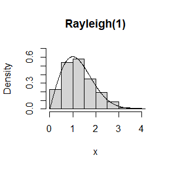

```r
sig<-1
hist(RL(sig),prob=TRUE,xlab = "x",main = "Rayleigh(1)",ylim=c(0,0.7))
y<-seq(0,10,0.01)
lines(y,(y/sig^2)*exp(-(y^2)/(2*sig^2)))
```

当$\sigma=2$时，随机数直方图及概率密度函数曲线如图所示：

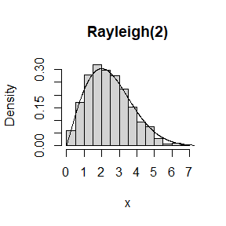

```r
sig<-2
hist(RL(sig),prob=TRUE,xlab = "x",main = "Rayleigh(2)")
y<-seq(0,10,0.01)
lines(y,(y/sig^2)*exp(-(y^2)/(2*sig^2)))
```

当$\sigma=4$时，随机数直方图及概率密度函数曲线如图所示：

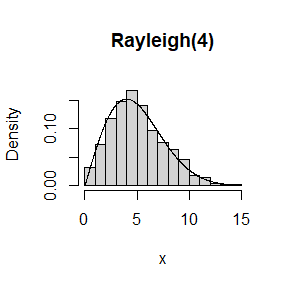

```r
sig<-4
hist(RL(sig),prob=TRUE,xlab = "x",main = "Rayleigh(4)",ylim = c(0,0.18))
y<-seq(0,15,0.01)
lines(y,(y/sig^2)*exp(-(y^2)/(2*sig^2)))
```

由此可见，在给定几种$\sigma>0$的情况下，随机数直方图与概率密度函数曲线均吻合得较好。

## 第二题 3.11

混合分布的概率密度函数为
$$f(x)=p_1\frac{1}{\sqrt{2\pi}}e^{-\frac{x^2}{2}}+(1-p_1)\frac{1}{\sqrt{2\pi}}e^{-\frac{(x-3)^2}{2}}$$
当$p_1=0.75$时：

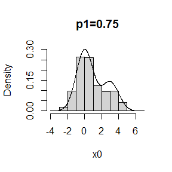

```r
set.seed(1234)
N<-1000
p1<-0.75
x1<-rnorm(N,0,1)
x2<-rnorm(N,3,1)
M<-matrix(0,N,2)
for (i in 1:N) {
  M[i,sample(x=c(1,2),size = 1,prob = c(p1,1-p1))]<-1
}
x0<-x1*M[,1]+x2*M[,2]#产生混合正态分布随机数
hist(x0,prob=TRUE,ylim =c(0,0.3),main = "p1=0.75")
y<-seq(-4,6,0.01)
lines(y,p1/sqrt(2*pi)*exp(-y^2/2)+(1-p1)/sqrt(1*pi)*exp(-(y-3)^2/2))
```

观察图像，可以看出图像似乎是双峰混合的。

改变$p_1$的取值，当$p_1=0.5$时：

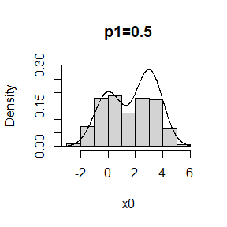

```r
set.seed(1234)
N<-1000
p1<-0.5
x1<-rnorm(N,0,1)
x2<-rnorm(N,3,1)
M<-matrix(0,N,2)
for (i in 1:N) {
  M[i,sample(x=c(1,2),size = 1,prob = c(p1,1-p1))]<-1
}
x0<-x1*M[,1]+x2*M[,2]#产生混合正态分布随机数
hist(x0,prob=TRUE,ylim =c(0,0.3),main = "p1=0.5")
y<-seq(-4,6,0.01)
lines(y,p1/sqrt(2*pi)*exp(-y^2/2)+(1-p1)/sqrt(1*pi)*exp(-(y-3)^2/2))
```

当$p_1=0.25$时：

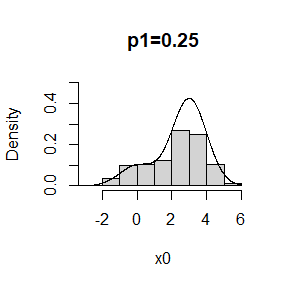

```r
set.seed(1234)
N<-1000
p1<-0.25
x1<-rnorm(N,0,1)
x2<-rnorm(N,3,1)
M<-matrix(0,N,2)
for (i in 1:N) {
  M[i,sample(x=c(1,2),size = 1,prob = c(p1,1-p1))]<-1
}
x0<-x1*M[,1]+x2*M[,2]#产生混合正态分布随机数
hist(x0,prob=TRUE,ylim =c(0,0.5),main = "p1=0.25")
y<-seq(-4,6,0.01)
lines(y,p1/sqrt(2*pi)*exp(-y^2/2)+(1-p1)/sqrt(1*pi)*exp(-(y-3)^2/2))
```

因此可以推测，当$p_1=0.5$时，图像会出现双峰的情况。

## 第三题 3.20

取泊松分布参数$\lambda=10$，伽马分布参数$\alpha=0.5$,$\beta=2$：

```r
set.seed(1234)
t<-10
lambda<-10
alpha<-0.5
beta<-2
m<-1000#取1000次重复实验
X_t<-rep(0,m)
Y_1<-rep(0,m)
for(i in 1:m){
  N<-rpois(t,lambda*t)
Y<-rgamma(N[t],shape = 0.5,rate = 2)
X_t[i]<-sum(Y)
Y_1[i]<-Y[1]
}
mean(X_t)#E[X(t)]
```

```
## [1] 25.13124
```

```r
lambda*t*mean(Y_1)
```

```
## [1] 25.65751
```

```r
var(X_t)#Var(X(t))
```

```
## [1] 18.15284
```

```r
lambda*t*mean(Y_1^2)
```

```
## [1] 18.08263
```

观察结果可知，在本次参数的设定下，$E[X(t)]$与$\lambda tE[Y_1]$近似相等，$Var(X(t))$与$\lambda tE[Y_1^2]$近似相等。

更改参数，取泊松分布参数$\lambda=12$，伽马分布参数$\alpha=2$，$\beta=0.3$：

```r
set.seed(1234)
t<-10
lambda<-12
alpha<-2
beta<-0.3
m<-1000#取1000次重复实验
X_t<-rep(0,m)
Y_1<-rep(0,m)
for(i in 1:m){
  N<-rpois(t,lambda*t)
Y<-rgamma(N[t],shape = 0.5,rate = 2)
X_t[i]<-sum(Y)
Y_1[i]<-Y[1]
}
mean(X_t)#E[X(t)]
```

```
## [1] 30.27608
```

```r
lambda*t*mean(Y_1)
```

```
## [1] 30.63235
```

```r
var(X_t)#Var(X(t))
```

```
## [1] 22.42302
```

```r
lambda*t*mean(Y_1^2)
```

```
## [1] 23.35014
```

取泊松分布参数$\lambda=5$，伽马分布参数$\alpha=0.8$，$\beta=5$：

```r
set.seed(1234)
t<-10
lambda<-5
alpha<-0.8
beta<-5
m<-1000#取1000次重复实验
X_t<-rep(0,m)
Y_1<-rep(0,m)
for(i in 1:m){
  N<-rpois(t,lambda*t)
Y<-rgamma(N[t],shape = 0.5,rate = 2)
X_t[i]<-sum(Y)
Y_1[i]<-Y[1]
}
mean(X_t)#E[X(t)]
```

```
## [1] 12.59072
```

```r
lambda*t*mean(Y_1)
```

```
## [1] 12.87251
```

```r
var(X_t)#Var(X(t))
```

```
## [1] 9.395538
```

```r
lambda*t*mean(Y_1^2)
```

```
## [1] 9.435883
```

取泊松分布参数$\lambda=15$，伽马分布参数$\alpha=5$，$\beta=8$：

```r
set.seed(1234)
t<-10
lambda<-15
alpha<-5
beta<-8
m<-1000#取1000次重复实验
X_t<-rep(0,m)
Y_1<-rep(0,m)
for(i in 1:m){
  N<-rpois(t,lambda*t)
Y<-rgamma(N[t],shape = 0.5,rate = 2)
X_t[i]<-sum(Y)
Y_1[i]<-Y[1]
}
mean(X_t)#E[X(t)]
```

```
## [1] 37.58102
```

```r
lambda*t*mean(Y_1)
```

```
## [1] 37.08484
```

```r
var(X_t)#Var(X(t))
```

```
## [1] 29.39866
```

```r
lambda*t*mean(Y_1^2)
```

```
## [1] 30.06573
```

综上所述，在多次改变泊松分布与伽马分布参数的情况下，可以观察到$X(10)$的均值和方差均与理论值近似相等。

# HW2

## 5.4

Beta(3,3)的概率密度函数为：
$$f(x;3,3)=\frac{1}{B(3,3)}x^2(1-x)^2$$
其中$B(3,3)=\int_0^1t^2(1-t)^2dt=\frac{1}{30}$ 因此
$$f(x;3,3)=30x^2(1-x)^2$$
$$F(x)=\int_0^x30u^2(1-u)^2du$$
令$y=u/x$，则$du=xdy$，且
$$\theta=\int_0^130x^3y^2(1-xy)^2dy$$
因此$\theta=E_Y[30x^3Y^2(1-xY)^2]$

```r
x<-seq(0.1,0.9,0.1)
m<-10000
u<-runif(m)#Y~U(0,1)
cdf<-numeric(length(x))
for (i in 1:length(x)) {
  g<-30*x[i]^3*u^2*(1-x[i]*u)^2
  cdf[i]<-mean(g)
}
Phi<-pbeta(x,3,3)
print(round(rbind(x,cdf,Phi),3))
```

```
##      [,1]  [,2]  [,3]  [,4]  [,5]  [,6]  [,7]  [,8]  [,9]
## x   0.100 0.200 0.300 0.400 0.500 0.600 0.700 0.800 0.900
## cdf 0.008 0.057 0.162 0.315 0.497 0.680 0.835 0.943 0.995
## Phi 0.009 0.058 0.163 0.317 0.500 0.683 0.837 0.942 0.991
```

## 5.9

```r
RL_sam<-function(sigma,R=1000,antithetic=TRUE){#服从Rayleigh分布的样本产生函数
  u<-runif(R/2)
  if(!antithetic){
    v<-runif(R/2)
    }
  else{
    v<-1-u
  }
  u<-c(u,v)
  x<-sqrt(-2*sigma^2*log(1-u))
  return(mean(x))
}
RL_sam(2,R=1000)
```

```
## [1] 2.518128
```

```r
RL_sam(5)
```

```
## [1] 6.258433
```

```r
RL_sam(0.2)
```

```
## [1] 0.2510974
```

取$\sigma=2$

```r
set.seed(1234)
m<-1000
MC1<-MC2<-numeric(m)
sig<-2
for (i in 1:m) {
  MC1[i]<-RL_sam(sigma = sig,R=1000,antithetic = FALSE)#普通独立抽样
  MC2[i]<-RL_sam(sigma = sig,R=1000)#对偶
}
print(sd(MC1))
```

```
## [1] 0.04136003
```

```r
print(sd(MC2))
```

```
## [1] 0.009733093
```

```r
round((var(MC1)-var(MC2))/var(MC1),4)
```

```
## [1] 0.9446
```

由此可见，在$\sigma=2$条件下，使用对偶变量法可以使方差缩减达到94.46%

取$\sigma=0.5$

```r
set.seed(1234)
m<-1000
MC1<-MC2<-numeric(m)
sig<-0.5
for (i in 1:m) {
  MC1[i]<-RL_sam(sigma = sig,R=1000,antithetic = FALSE)#普通独立抽样
  MC2[i]<-RL_sam(sigma = sig,R=1000)#对偶
}

print(sd(MC1))
```

```
## [1] 0.01034001
```

```r
print(sd(MC2))
```

```
## [1] 0.002433273
```

```r
round((var(MC1)-var(MC2))/var(MC1),4)
```

```
## [1] 0.9446
```

由此可见，在$\sigma=0.5$条件下，使用对偶变量法可以使方差缩减达到94.46%

## 5.13

选择$f_1=\frac{1}{\sqrt{2\pi}}e^{-x^2/2}$（标准正态分布） $f_2=xe^{-x^2/2}$(Rayleigh(1)分布)

```r
set.seed(1234)
m<-10000
theta.hat<-se<-numeric(2)
g<-function(x){
  x^2/sqrt(2*pi)*exp(-x^2/2)*(x>1)
}
x<-rnorm(m)#令f1为重要函数
fg<-g(x)/dnorm(x)
theta.hat[1]<-mean(fg)
se[1]<-sd(fg)

u<-runif(m)#令f2为重要函数，并使用逆变换法
x<-sqrt(-2*log(1-u))
fg<-g(x)/(x*exp(-x^2/2))
theta.hat[2]<-mean(fg)
se[2]<-sd(fg)

rbind(theta.hat,se)
```

```
##               [,1]      [,2]
## theta.hat 0.389357 0.4068302
## se        1.117100 0.3593336
```

观察结果可知使用重要函数$f_2=xe^{-x^2/2}$产生的方差更小，原因是$f_2$与待估计的$g(x)$更加接近

## 蒙特卡洛实验

```r
quick_sort<-function(x){
  num<-length(x)
  if(num==0||num==1){return(x)
  }else{
    a<-x[1]
    y<-x[-1]
    lower<-y[y<a]
    upper<-y[y>=a]
    return(c(quick_sort(lower),a,quick_sort(upper)))}
}

time_com<-function(N){
  a<-numeric(100)
for (i in 1:100) {
  test<-sample(1:N)
a[i]<-system.time(quick_sort(test))[1]
}
return(mean(a))
}

t_fun<-function(n){
  return(n*log(n))
}
```

```r
set.seed(1234)
an<-c(time_com(1e4),time_com(2e4),time_com(4e4),time_com(6e4),time_com(8e4))
tn<-c(t_fun(1e4),t_fun(2e4),t_fun(4e4),t_fun(6e4),t_fun(8e4))
```

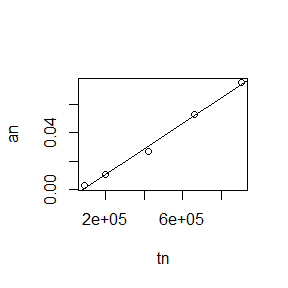

```r
plot(tn,an)
abline(lm(an~tn)$coef[1],lm(an~tn)$coef[2])
```

# HW3

## 第一题6.6

```r
set.seed(1234)
m<-1000
sk<-numeric(m)
for (i in 1:m) {
  x<-rnorm(1000)
  sk[i]<-mean(((x-mean(x))/sd(x))^3)
}

p<-c(0.025,0.05,0.95,0.975)
q_mc<-quantile(sk,p)
sd_sk<-numeric(4)
for(i in 1:4){
  sd_sk[i]<-sqrt(p[i]*(1-p[i])/(m*dnorm(q_mc[i],0,sqrt(6/m))^2))
}
q_mc#蒙特卡洛估计分位数
```

```
##       2.5%         5%        95%      97.5%
## -0.1528197 -0.1280073  0.1304050  0.1481647
```

```r
qnorm(p,0,sqrt(6/m))#大样本近似分位数
```

```
## [1] -0.1518182 -0.1274098  0.1274098  0.1518182
```

```r
sd_sk#标准差
```

```
## [1] 0.006711846 0.005242479 0.005520277 0.005972214
```

观察结果可知，由蒙特卡洛方法估计出的分位数与大样本近似分位数较为接近。

## 第二题6.B

```r
library(MASS)
set.seed(123)
n<-100
mu<-c(0,0)
sigma <- matrix(c(1, 0.5, 0.5, 1), 2, 2)
data <- mvrnorm(n, mu, sigma)#产生(X,Y)

pearson_test <- cor.test(data[,1],data[,2],method = "pearson")#Pearson相关系数检验
pearson_test$p.value
```

```
## [1] 1.866227e-06
```

```r
spearman_test <- cor.test(data[,1],data[,2],method = "spearman")#Spearman秩相关系数检验
spearman_test$p.value
```

```
## [1] 7.933005e-06
```

```r
kendall_test <- cor.test(data[,1],data[,2],method = "kendall")#Kendall系数检验
kendall_test$p.value
```

```
## [1] 6.893313e-06
```

观察结果可知，Pearson相关系数检验的p值最小，即拥有比Spearman秩相关系数检验和Kendall系数检验更好的经验功效。

一个特例：$y=2x^2+e$

```r
set.seed(123)
n<-100
X0<-rnorm(n)
Y0<-2*X0^2+rnorm(n)

pearson_test <- cor.test(X0,Y0,method = "pearson")#Pearson相关系数检验
pearson_test$p.value
```

```
## [1] 0.1105087
```

```r
spearman_test <- cor.test(X0,Y0,method = "spearman")#Spearman秩相关系数检验
spearman_test$p.value
```

```
## [1] 0.1367692
```

```r
kendall_test <- cor.test(X0,Y0,method = "kendall")#Kendall系数检验
kendall_test$p.value
```

```
## [1] 0.07689365
```

在这种情况下，Kendall系数检验的p值最小，即拥有比Pearson相关系数检验更好的经验功效。

## 第三题

If we obtain the powers for two methods under a particular simulation setting with 10,000 experiments: say, 0.651 for one method and 0.676 for another method. We want to know if the powers are different at 0.05 level. 1. What is the corresponding hypothesis test problem? 2. What test should we use? Z-test, two-sample t-test, paired-t-test or McNemar test? Why? 3. Please provide the least necessary information for hypothesis testing.

1.对应的假设检验为： $H_0$：两种方法的功效相同 $H_1$：两种方法的功效不同

2.应该采用Z检验方法，因为试验次数足够大，且不是配对数据，也不是二分数据。

3.设$p_1=0.651$，$p_2=0.676$，则在显著性水平$\alpha=0.05$下，Z检验统计量为
$$Z=\frac{p_1-p_2}{\sqrt{p(1-p)(\frac{1}{n_1}+\frac{1}{n_2})}}$$

```r
1-pnorm(3.09)
```

```
## [1] 0.001000782
```

由于p值=0.001，小于显著性水平$\alpha$（0.05），因此拒绝$H_0$，并得出结论：在显著性水平为0.05下，两种方法的功效是不同的。

# 课堂作业

```r
set.seed(1234)
 d1 <- c(-2.961, 0.478, -0.391, -0.869, -0.460,
            -0.937, 0.779, -1.409, 0.027, -1.569)
d2  <- c(1.608, 1.009,  0.878,  1.600, -0.263,
             0.680, 2.280,  2.390, 1.793,  8.091, 1.468)
mean_d1 <- mean(d1)
mean_d2 <- mean(d2)

# 计算均值差异
mean_diff <- mean_d2 - mean_d1

# 计算样本标准误差
n1 <- length(d1)
n2 <- length(d2)
se_diff <- sqrt((sd(d1)^2 / n1) + (sd(d2)^2 / n2))

R <- 10000

bootstrap_diffs <- numeric(R)

# 生成自助样本并计算均值差异
for (i in 1:R) {
  d1_bootstrap <- sample(d1, replace = TRUE)
  d2_bootstrap <- sample(d2, replace = TRUE)
  mean_d1_bootstrap <- mean(d1_bootstrap)
  mean_d2_bootstrap <- mean(d2_bootstrap)
  bootstrap_diffs[i] <- mean_d2_bootstrap - mean_d1_bootstrap
}

# 计算自助标准误差
bootstrap_se_diff <- sd(bootstrap_diffs)

round(c(bias=mean(bootstrap_diffs)-mean_diff,se.boot=bootstrap_se_diff,se.samp=se_diff),3)
```

```
##    bias se.boot se.samp
##  -0.003   0.708   0.739
```

# HW4

## 1.

Of N = 1000 hypotheses, 950 are null and 50 are alternative. The p-value under any null hypothesis is uniformly distributed (use runif), and the p-value under any alternative hypothesis follows the beta distribution with parameter 0.1 and 1 (use rbeta). Obtain Bonferroni adjusted p-values and B-H adjusted p-values. Calculate FWER, FDR, and TPR under nominal level α = 0.1 for each of the two adjustment methods based on m = 10000 simulation replicates. You should output the 6 numbers (3 ) to a 3 × 2 table (column names: Bonferroni correction, B-H correction; row names: FWER, FDR, TPR). Comment the results.

```r
set.seed(1234)
N <- 1000
n1 <- 950  #null
n2 <- 50   #alter
alpha <- 0.1
m <- 10000

fwer_bf <- numeric(m)
fdr_bf <- numeric(m)
tpr_bf <- numeric(m)

fwer_bh <- numeric(m)
fdr_bh <- numeric(m)
tpr_bh <- numeric(m)

for (i in 1:m) {
  #生成p值
  p_values <- c(runif(n1), rbeta(n2, 0.1, 1))

  #调整p值
  bf_adjusted_p_values <- rbind(p.adjust(p_values, method = "bonferroni"))
  bh_adjusted_p_values <- rbind(p.adjust(p_values, method = "BH"))

  #拒绝
  bf_rejected <- bf_adjusted_p_values < alpha
  bh_rejected <- bh_adjusted_p_values < alpha

  # 计算FWER, FDR, TPR
  fwer_bf[i] <- any(bf_rejected[1:n1])
  fdr_bf[i] <- sum(bf_rejected[1:n1]) / sum(bf_rejected)
  tpr_bf[i] <- sum(bf_rejected[(n1+1):N]) / n2
  fwer_bh[i] <- any(bh_rejected[1:n1])
  fdr_bh[i] <- sum(bh_rejected[1:n1]) / sum(bh_rejected)
  tpr_bh[i] <- sum(bh_rejected[(n1+1):N]) / n2
}

fwer_bf_mean <- mean(fwer_bf)
fdr_bf_mean <- mean(fdr_bf)
tpr_bf_mean <- mean(tpr_bf)
fwer_bh_mean <- mean(fwer_bh)
fdr_bh_mean <- mean(fdr_bh)
tpr_bh_mean <- mean(tpr_bh)

results <- rbind(
  c(fwer_bf_mean, fwer_bh_mean),
  c(fdr_bf_mean, fdr_bh_mean),
  c(tpr_bf_mean, tpr_bh_mean)
)
colnames(results) <- c("Bonferroni", "BH")
rownames(results) <- c("FWER", "FDR", "TPR")

print(results)
```

```
##       Bonferroni         BH
## FWER 0.091000000 0.93330000
## FDR  0.004643915 0.09442065
## TPR  0.398562000 0.56312400
```

FWER：Bonferroni方法的FWER小于显著性水平0.1。B-H方法则相对不那么保守，它的FWER明显更大。

FDR：两种方法都小于显著性水平0.1

TPR：Bonferroni方法的TPR较低，表明它在保持低FDR的同时，可能会错过一些真正的效应。B-H方法则能发现更多的真正备择假设，因此其TPR更高。

## 2.

由于故障间隔时间服从$Exp(\lambda)$分布，因此其概率密度函数为$f(t)=\lambda e^{-\lambda t}$ 在给定数据$x_1,\ldots,x_n$下，似然函数为
$$L(\lambda)=\prod_{i=1}^n f(x_i)=\prod_{i=1}^n
\lambda e^{-\lambda x_i}=\lambda e^{-\lambda \sum_{i=1}^n x_i}$$
对数似然函数为
$$l(\lambda)=nln(\lambda)-\lambda \sum_{i=1}^n
x_i$$
$$\frac{\partial
l(\lambda)}{\partial \lambda}=\frac{n}{\lambda}-\sum_{i=1}^n
x_i=0$$
$$\hat{\lambda}=\frac{n}{\sum_{i=1}^n
x_i}$$

```r
library(boot)
set.seed(1234)
data<-as.vector(aircondit$hours)
#极大似然函数
mle_lambda <- function(data, indices) {
  n <- length(data[indices])
  return(n / sum(data[indices]))
}
obj<-boot(data,statistic = mle_lambda,R=1e4)
obj
```

```
##
## ORDINARY NONPARAMETRIC BOOTSTRAP
##
##
## Call:
## boot(data = data, statistic = mle_lambda, R = 10000)
##
##
## Bootstrap Statistics :
##       original      bias    std. error
## t1* 0.00925212 0.001295651 0.004218273
```

## 3.

```r
set.seed(1234)
m<-1e3
ci.norm<-ci.basic<-ci.perc<-ci.bca<-matrix(NA,m,2)
for (i in 1:m) {
  de<-boot(data,statistic = mle_lambda,R=999)
  ci<-boot.ci(de,type = c("norm","basic","perc","bca"))
  ci.norm[i,]<-ci$norm[2:3]
  ci.basic[i,]<-ci$basic[4:5]
  ci.perc[i,]<-ci$percent[4:5]
  ci.bca[i,]<-ci$bca[4:5]
}
cat("normal:", mean(ci.norm[,1]),mean(ci.norm[,2]), "\n")
```

```
## normal: -0.000513643 0.01637695
```

```r
cat("basic:", mean(ci.basic[,1]),mean(ci.basic[,2]), "\n")
```

```
## basic: -0.002946922 0.01327646
```

```r
cat("percentile:", mean(ci.perc[,1]),mean(ci.perc[,2]), "\n")
```

```
## percentile: 0.005227779 0.02145116
```

```r
cat("bca:", mean(ci.bca[,1]),mean(ci.bca[,2]), "\n")
```

```
## bca: 0.004561807 0.01806598
```

由于时间间隔服从指数分布，并不是正态的，因此normal方法与basic方法不够准确；在这种分布下，percentile方法与bca方法较为准确，它们之间也比较接近。

# HW5

## 1.

7.8

```r
library(bootstrap)
df<-scor
sort_eigen<- sort(eigen(cov(df))$values, decreasing = TRUE)
theta_hat <- sort_eigen[1] / sum(sort_eigen)
n <- nrow(df)
jackknife_estimates <- numeric(n)
for (i in 1:n) {
  leave_one_out <- df[-i, ]
  sample_cov_matrix <- cov(leave_one_out)
  eigenvalues <- eigen(sample_cov_matrix)$values
  sorted_eigenvalues <- sort(eigenvalues, decreasing = TRUE)
  jackknife_estimates[i] <- sorted_eigenvalues[1] / sum(sorted_eigenvalues)
}
bias.jack<-(n-1)*(mean(jackknife_estimates)-theta_hat)
se.jack<-sqrt((n-1)*mean((jackknife_estimates-theta_hat)^2))
round(c(original=theta_hat,bias.jack=bias.jack,se.jack=se.jack),3)
```

```
##  original bias.jack   se.jack
##     0.619     0.001     0.050
```

## 2.

7.10

```r
set.seed(1234)
library(DAAG)
attach(ironslag)
n <- length(magnetic) #in DAAG ironslag
e1 <- e2 <- e3 <- e4 <- numeric(n)

for (k in 1:n) {
y <- magnetic[-k]
x <- chemical[-k]

J1 <- lm(y ~ x)
yhat1 <- J1$coef[1] + J1$coef[2] * chemical[k]
e1[k] <- magnetic[k] - yhat1

J2 <- lm(y ~ x + I(x^2))
yhat2 <- J2$coef[1] + J2$coef[2] * chemical[k] +J2$coef[3] * chemical[k]^2
e2[k] <- magnetic[k] - yhat2

J3 <- lm(log(y) ~ x)
logyhat3 <- J3$coef[1] + J3$coef[2] * chemical[k]
yhat3 <- exp(logyhat3)
e3[k] <- magnetic[k] - yhat3

J4 <- lm(y ~ x + I(x^2) + I(x^3))
yhat4 <- J4$coef[1] + J4$coef[2] * chemical[k] + J4$coef[3] * chemical[k]^2 + J4$coef[4] * chemical[k]^3
e4[k] <- magnetic[k] - yhat4
}

c(mean(e1^2), mean(e2^2), mean(e3^2), mean(e4^2))
```

```
## [1] 19.55644 17.85248 18.44188 18.17756
```

由交叉验证结果可知，应该选择模型2

```r
L1 <- lm(magnetic ~ chemical)
L2 <- lm(magnetic ~ chemical + I(chemical^2))
L3 <- lm(log(magnetic) ~ chemical)
L4 <- lm(magnetic ~ chemical + I(chemical^2)+ I(chemical^3))
c(summary(L1)$adj.r.squared,summary(L2)$adj.r.squared,summary(L3)$adj.r.squared,summary(L4)$adj.r.squared)
```

```
## [1] 0.5281545 0.5768151 0.5280556 0.5740396
```

由adjusted $R^2$结果可知，应该选择模型2

## 3.

8.1

```r
set.seed(1234)
attach(chickwts)
x <- sort(as.vector(weight[feed == "soybean"]))
y <- sort(as.vector(weight[feed == "linseed"]))
detach(chickwts)

cvm_statistic <- function(x, y) {
  n <- length(x)
  m <- length(y)
  Fn <- ecdf(x)
  Gm <- ecdf(y)
  cvm <- m*n/((m+n)^2)*(sum((Fn(x)-Gm(x))^2)+sum((Fn(y)-Gm(y))^2))
  return(cvm)
}

R <- 999 #number of replicates
z <- c(x, y) #pooled sample
K <- 1:26
reps <- numeric(R) #storage for replicates
cvm0 <- cvm_statistic(x, y)
for (i in 1:R) {
#generate indices k for the first sample
k <- sample(K, size = 14, replace = FALSE)
x1 <- z[k]
y1 <- z[-k] #complement of x1
reps[i] <- cvm_statistic(x1, y1)
}
p<-mean(c(cvm0,reps)>=cvm0)
p
```

```
## [1] 0.414
```

## 4.

8.2

```r
set.seed(123)
n<-50
x <- rnorm(n)
y <- 0.5 * x + rnorm(n)# x服从标准正态分布，y与x有一定的线性关系
R <- 999
z <- c(x, y) #pooled sample
K <- 1:(2*n)
reps <- numeric(R) #storage for replicates
rho0 <- cor(x, y, method = "spearman")
for (i in 1:R) {
#generate indices k for the first sample
k <- sample(K, size = n, replace = FALSE)
x1 <- z[k]
y1 <- z[-k] #complement of x1
reps[i] <- cor(x1,y1, method = "spearman")
}
p<-mean(abs(c(rho0,reps))>=abs(rho0))
cat("原始Spearman秩相关系数:", rho0, "\n")
```

```
## 原始Spearman秩相关系数: 0.4439376
```

```r
cat("置换检验得到的p值:", p, "\n")
```

```
## 置换检验得到的p值: 0.002
```

```r
cat("cor.test函数得到的p值:",cor.test(x, y, method = "spearman")$p.value, "\n")
```

```
## cor.test函数得到的p值: 0.001378478
```

# HW6

## 1、9.3

```r
# 设置参数
set.seed(1234)
theta <- 1
eta <- 0     # Cauchy
n <- 5000    # 生成样本的总数量
burn_in <- 1000   # 丢弃的前1000个样本
samples <- numeric(n)
samples[1] <- rnorm(1)  # 初始化链的第一个样本

for (i in 2:n) {
  candidate <- samples[i - 1] + rnorm(1, mean = 0, sd = 1)
  alpha <- min(1, (dcauchy(candidate, location = eta, scale = theta)))
  if (runif(1) < alpha) {
    samples[i] <- candidate
  } else {
    samples[i] <- samples[i - 1]
  }# 接受或拒绝候选样本
}
samples <- samples[(burn_in + 1):n]#丢弃前1000个样本
gene_qt <- quantile(samples, probs = seq(0.1, 0.9, by = 0.1))#产生的样本分位数
theo_qt <- qcauchy(seq(0.1, 0.9, by = 0.1), location = eta, scale = theta)#理论分位数
result <- data.frame(Decile = seq(0.1, 0.9, by = 0.1),
                     Generated = gene_qt,
                     Theoretical = theo_qt)
print(result)
```

```
##     Decile  Generated Theoretical
## 10%    0.1 -1.3051588  -3.0776835
## 20%    0.2 -0.7282962  -1.3763819
## 30%    0.3 -0.4647887  -0.7265425
## 40%    0.4 -0.2030557  -0.3249197
## 50%    0.5  0.1008800   0.0000000
## 60%    0.6  0.4015867   0.3249197
## 70%    0.7  0.7852227   0.7265425
## 80%    0.8  1.3587765   1.3763819
## 90%    0.9  3.8769703   3.0776835
```

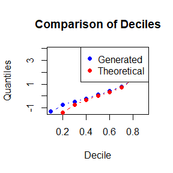

```r
plot(seq(0.1, 0.9, by = 0.1), gene_qt, type = "b", pch = 19, col = "blue",
     xlab = "Decile", ylab = "Quantiles", main = "Comparison of Deciles")
points(seq(0.1, 0.9, by = 0.1), theo_qt, type = "b", pch = 19, col = "red")
legend("topright", legend = c("Generated", "Theoretical"), col = c("blue", "red"), pch = 19)
```

观察图像可知，Metropolis-Hastings采样器产生的柯西分布样本的十分位数与理论值较为接近。

## 2、9.8

选定a=2，b=3，n=10进行模拟

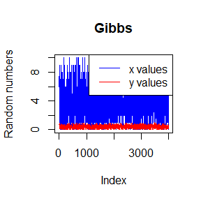

```r
set.seed(1234)
a <- 2
b <- 3
n <- 10
iterations <- 5000  # 迭代次数
burn_in <- 1000
x_samples <- numeric(iterations)
y_samples <- numeric(iterations)
y_samples[1] <- 0.5  # 初始化 y 值
for (i in 2:iterations) {
  x_samples[i] <- rbinom(1, size = n, prob = y_samples[i - 1])#根据当前y值获得x
  y_samples[i] <- rbeta(1, shape1 = x_samples[i] + a, shape2 = n - x_samples[i] + b)#根据当前x值获得y
}
x_samples <- x_samples[(burn_in + 1):iterations]
y_samples <- y_samples[(burn_in + 1):iterations]#丢弃

plot(x_samples, type = "l", col = "blue", lwd = 1.5,
     main = "Gibbs", xlab = "Index", ylab = "Random numbers",
     ylim = range(c(x_samples, y_samples)))
lines(y_samples, type = "l", col = "red", lwd = 1.5)
legend("topright", legend = c("x values", "y values"), col = c("blue", "red"), lwd = 1.5)
```

## 3、

9.3

```r
library(coda)
set.seed(1)
iterations <- 5000
burn_in <- 1000
num_chains <- 3
target_dist <- function(x) dcauchy(x)  #标准柯西分布
MH_sampler <- function(init, n_iter, proposal_sd = 1) {
  x <- numeric(n_iter)
  x[1] <- init
  for (i in 2:n_iter) {
    proposal <- rnorm(1, mean = x[i - 1], sd = proposal_sd)
    accept_prob <- min(1, target_dist(proposal) / target_dist(x[i - 1]))
    x[i] <- ifelse(runif(1) < accept_prob, proposal, x[i - 1])
  }
  return(x)
}
chains <- matrix(NA, nrow = iterations - burn_in, ncol = num_chains)
for (chain in 1:num_chains) {
  init_value <- rnorm(1)
  full_chain <- MH_sampler(init_value, iterations)
  chains[, chain] <- full_chain[(burn_in + 1):iterations]  # 丢弃
}
mcmc_chains <- mcmc.list(lapply(1:num_chains, function(i) mcmc(chains[, i])))
gelman_results <- gelman.diag(mcmc_chains)
print(gelman_results)
```

```
## Potential scale reduction factors:
##
##      Point est. Upper C.I.
## [1,]       1.04       1.14
```

观察结果可知此时链收敛

9.8

```r
library(coda)
set.seed(1)
a <- 2
b <- 3
n <- 10
iterations <- 5000
burn_in <- 1000
num_chains <- 3
x_chains <- matrix(0, nrow = iterations - burn_in, ncol = num_chains)
y_chains <- matrix(0, nrow = iterations - burn_in, ncol = num_chains)
for (chain in 1:num_chains) {
  x_samples <- numeric(iterations)
  y_samples <- numeric(iterations)
  y_samples[1] <- 0.5
  for (i in 2:iterations) {
    x_samples[i] <- rbinom(1, size = n, prob = y_samples[i - 1])#根据当前y值获得x
    y_samples[i] <- rbeta(1, shape1 = x_samples[i] + a, shape2 = n - x_samples[i] + b)#根据当前x值获得y
  }
  x_chains[, chain] <- x_samples[(burn_in + 1):iterations]
  y_chains[, chain] <- y_samples[(burn_in + 1):iterations]
}
x_mcmc <- mcmc.list(lapply(1:num_chains, function(i) mcmc(x_chains[, i])))
y_mcmc <- mcmc.list(lapply(1:num_chains, function(i) mcmc(y_chains[, i])))
gelman_x <- gelman.diag(x_mcmc)
gelman_y <- gelman.diag(y_mcmc)
print(gelman_x)
```

```
## Potential scale reduction factors:
##
##      Point est. Upper C.I.
## [1,]          1       1.01
```

```r
print(gelman_y)
```

```
## Potential scale reduction factors:
##
##      Point est. Upper C.I.
## [1,]          1       1.01
```

观察结果可知此时链收敛

# HW7

## 1、

11.3

```r
library(pracma)
library(base)
kth_term <- function(k, a, d) {#计算第k个式子
  norm_a<-sqrt(sum(a^2))#欧式范数
  numerator<-(-1)^k/(factorial(k)*2^k)*(norm_a)^(2*k+2)/((2*k+1)*(2*k+2))#前两项乘积
  gamma_factor<-gamma((d+1)/2)*gamma(k+3/2)/gamma(k+d/2+1)#第三项
  term <- numerator* gamma_factor
  return(term)
}

sum_series <- function(a,d,tol=1e-10) {#求和
  sum<-0
  k<-0
  repeat {
    term<-kth_term(k, a, d)
    sum<-sum+term
    if(abs(term)<tol) break
    k<-k+1
  }
  return(sum)
}

a<-c(1, 2)
d<-length(a)
sum_series(a, d)#给定a=(1,2)^T时求和结果
```

```
## [1] 1.532164
```

## 2、11.5

```r
library(stats)
c_k<-function(a,k){
  return(sqrt(((a^2)*k)/(k+1-a^2)))
}
LHS<-function(a,k){#等号左边
  ck_1<-c_k(a,k-1)
  if (is.nan(ck_1) || ck_1 <= 0) {
    return(NA)  # 返回 NA 以避免无效积分
  }
  integrand<-function(u){#积分项
    (1+(u^2)/(k-1))^(-k/2)
  }
  integral_result<-integrate(integrand,0,ck_1)$value
  (2*gamma(k/2))/(sqrt(pi*(k-1))*gamma((k-1)/2))*integral_result
}
RHS<-function(a,k){#等号右边
  ck<-c_k(a, k)
  if (is.nan(ck) || ck <= 0) {
    return(NA)  # 返回 NA 以避免无效积分
  }
  integrand<-function(u){#积分项
    (1+(u^2)/k)^(-(k+1)/2)
  }
  integral_result<-integrate(integrand,0,ck)$value
  (2*gamma((k+1)/2))/(sqrt(pi*k)*gamma(k/2))*integral_result
}
objective_function<-function(a,k){#差值函数，越接近0说明LHS与RHS越接近
  LHS(a,k)-RHS(a,k)
}
find_intersection<-function(k){
suppressWarnings({
result<-optimize(function(a) {#寻找一个使得差值函数绝对值最接近0的值
  obj_val <- objective_function(a,k)
  if (is.na(obj_val)) return(Inf)  #如果值为NA,返回无穷大，表示不适合的解
  abs(obj_val)
}, c(0.01,sqrt(k)))
})
return(result$minimum)
}
k_values <- c(4, 25, 100, 500, 1000)
results <- sapply(k_values, find_intersection)
rbind(k_values,results)
```

```
##              [,1]      [,2]       [,3]      [,4]      [,5]
## k_values 4.000000 25.000000 100.000000 500.00000 1000.0000
## results  1.492084  4.855902   7.784183  22.36064   31.6227
```

结果展示了当k分别取4,25,100,500,1000时，满足方程的a的近似解。

与11.4中的A(k)比较：

11.4

```r
library(stats)
S_k_1 <- function(a, k) {
  threshold<-sqrt(a^2*(k-1)/(k-a^2))
  pt(threshold, df=k-1,lower.tail=FALSE)
}
S_k <- function(a, k) {
  threshold<-sqrt(a^2*k/(k+1-a^2))
  pt(threshold, df = k, lower.tail = FALSE)
}
objective_function <- function(a, k) {#差值函数
  S_k_1(a, k)-S_k(a, k)
}

find_intersection <- function(k) {#求根
  result <- tryCatch({
    uniroot(function(a) objective_function(a, k), c(0.01, sqrt(k) - 0.01))$root
  }, error = function(e) NA)
  return(result)
}

k_values <- c(4, 25, 100, 500, 1000)
results <- sapply(k_values, find_intersection)
rbind(k_values,results)
```

```
##              [,1]      [,2]       [,3]      [,4]       [,5]
## k_values 4.000000 25.000000 100.000000 500.00000 1000.00000
## results  1.492073  1.687366   1.720607  22.35068   31.61278
```

## 3、

由于$T_i\sim exp(\lambda)$，所以$f_{T_i}(t)=\lambda e^{-\lambda t}$，因此
$$f_{T_i|T_i>\tau}(t)=\frac{f_{T_i}(t)}{P(T_i>\tau)}=\frac{\lambda
e^{-\lambda t}}{e^{-\lambda \tau}}=\lambda e^{-\lambda
(t-\tau)}$$
观察概率密度函数可知这是一个偏移的条件分布，因此
$$E(T_i|T_i>\tau)=\tau+\frac{1}{\lambda}$$
因此更新后的$\lambda$为
$$\lambda_{new}=\frac{n}{\sum[T_i
I(T_i<\tau)+E(T_i|T_i>\tau)I(T_i>\tau)]}$$

```r
data<-c(0.54,0.48,0.33,0.43,1.00,1.00,0.91,1.00,0.21,0.85)
tau<-1
lambda<-1  #给定的初始λ值
n<-length(data)
max_iter<-100
tol<-1e-6
for (iter in 1:max_iter) {#EM算法
  expected_censored<-sum((data==tau)*(tau+1/lambda))#E步,计算T_i>tau时T_i的期望值
  lambda_new<-n/(sum(data[data<tau])+expected_censored)#M步
  if(abs(lambda_new-lambda)<tol){
    lambda<-lambda_new
    break
  }
  lambda<-lambda_new
}
lambda_mle<-1/mean(data)#MLE
lambda
```

```
## [1] 1.037037
```

```r
lambda_mle
```

```
## [1] 1.481481
```

# HW8

## 1、11.7

```r
library(boot) #for simplex function
A1 <- rbind(c(2, 1, 1), c(1, -1, 3))
b1 <- c(2, 3)
a <- c(4, 2, 9)
simplex(a = a, A1 = A1, b1 = b1, maxi = FALSE)
```

```
##
## Linear Programming Results
##
## Call : simplex(a = a, A1 = A1, b1 = b1, maxi = FALSE)
##
## Minimization Problem with Objective Function Coefficients
## x1 x2 x3
##  4  2  9
##
##
## Optimal solution has the following values
## x1 x2 x3
##  0  0  0
## The optimal value of the objective  function is 0.
```

因此当$x=y=z=0$时，$4x+2y+9z$有最小值0

## 2、advanced R P204 3

```r
formulas <- list(
mpg ~ disp,
mpg ~ I(1 / disp),
mpg ~ disp + wt,
mpg ~ I(1 / disp) + wt
)
for_loops<-list()
for (i in 1:length(formulas)) {#使用for循环
  for_loops[[i]]<-lm(formulas[[i]],data = mtcars)
}
for_loops
```

```
## [[1]]
##
## Call:
## lm(formula = formulas[[i]], data = mtcars)
##
## Coefficients:
## (Intercept)         disp
##    29.59985     -0.04122
##
##
## [[2]]
##
## Call:
## lm(formula = formulas[[i]], data = mtcars)
##
## Coefficients:
## (Intercept)    I(1/disp)
##       10.75      1557.67
##
##
## [[3]]
##
## Call:
## lm(formula = formulas[[i]], data = mtcars)
##
## Coefficients:
## (Intercept)         disp           wt
##    34.96055     -0.01772     -3.35083
##
##
## [[4]]
##
## Call:
## lm(formula = formulas[[i]], data = mtcars)
##
## Coefficients:
## (Intercept)    I(1/disp)           wt
##      19.024     1142.560       -1.798
```

```r
lapply(formulas, function(formula) lm(formula,data = mtcars))#使用lappy函数
```

```
## [[1]]
##
## Call:
## lm(formula = formula, data = mtcars)
##
## Coefficients:
## (Intercept)         disp
##    29.59985     -0.04122
##
##
## [[2]]
##
## Call:
## lm(formula = formula, data = mtcars)
##
## Coefficients:
## (Intercept)    I(1/disp)
##       10.75      1557.67
##
##
## [[3]]
##
## Call:
## lm(formula = formula, data = mtcars)
##
## Coefficients:
## (Intercept)         disp           wt
##    34.96055     -0.01772     -3.35083
##
##
## [[4]]
##
## Call:
## lm(formula = formula, data = mtcars)
##
## Coefficients:
## (Intercept)    I(1/disp)           wt
##      19.024     1142.560       -1.798
```

## 3、advanced R P204 4

```r
bootstraps <- lapply(1:10, function(i) {
rows <- sample(1:nrow(mtcars), rep = TRUE)
mtcars[rows, ]
})
for_loops<-list()
for (i in 1:length(bootstraps)) {#使用for循环
  for_loops[[i]]<-lm(mpg~disp,data = bootstraps[[i]])
}
for_loops
```

```
## [[1]]
##
## Call:
## lm(formula = mpg ~ disp, data = bootstraps[[i]])
##
## Coefficients:
## (Intercept)         disp
##    31.83577     -0.04923
##
##
## [[2]]
##
## Call:
## lm(formula = mpg ~ disp, data = bootstraps[[i]])
##
## Coefficients:
## (Intercept)         disp
##    27.43227     -0.03332
##
##
## [[3]]
##
## Call:
## lm(formula = mpg ~ disp, data = bootstraps[[i]])
##
## Coefficients:
## (Intercept)         disp
##     28.2985      -0.0383
##
##
## [[4]]
##
## Call:
## lm(formula = mpg ~ disp, data = bootstraps[[i]])
##
## Coefficients:
## (Intercept)         disp
##     30.4626      -0.0481
##
##
```

[output cut: 43 more lines]

```
## lm(formula = mpg ~ disp, data = bootstraps[[i]])
##
## Coefficients:
## (Intercept)         disp
##    30.92968     -0.04381
##
##
## [[10]]
##
## Call:
## lm(formula = mpg ~ disp, data = bootstraps[[i]])
##
## Coefficients:
## (Intercept)         disp
##    31.02797     -0.04598
```

```r
lapply(bootstraps, function(boo) lm(mpg~disp,data = boo))#使用lappy函数
```

```
## [[1]]
##
## Call:
## lm(formula = mpg ~ disp, data = boo)
##
## Coefficients:
## (Intercept)         disp
##    31.83577     -0.04923
##
##
## [[2]]
##
## Call:
## lm(formula = mpg ~ disp, data = boo)
##
## Coefficients:
## (Intercept)         disp
##    27.43227     -0.03332
##
##
## [[3]]
##
## Call:
## lm(formula = mpg ~ disp, data = boo)
##
## Coefficients:
## (Intercept)         disp
##     28.2985      -0.0383
##
##
## [[4]]
##
## Call:
## lm(formula = mpg ~ disp, data = boo)
##
## Coefficients:
## (Intercept)         disp
##     30.4626      -0.0481
##
##
```

[output cut: 43 more lines]

```
## lm(formula = mpg ~ disp, data = boo)
##
## Coefficients:
## (Intercept)         disp
##    30.92968     -0.04381
##
##
## [[10]]
##
## Call:
## lm(formula = mpg ~ disp, data = boo)
##
## Coefficients:
## (Intercept)         disp
##    31.02797     -0.04598
```

## 4、advanced R P204 5

第三题：

```r
rsq <- function(mod) summary(mod)$r.squared
formulas <- list(
mpg ~ disp,
mpg ~ I(1 / disp),
mpg ~ disp + wt,
mpg ~ I(1 / disp) + wt
)
for_loops<-list()
r_for<-numeric(length(formulas))
for (i in 1:length(formulas)) {#使用for循环
  for_loops[[i]]<-lm(formulas[[i]],data = mtcars)
  r_for[i]<-rsq(for_loops[[i]])
}
r_for
```

```
## [1] 0.7183433 0.8596865 0.7809306 0.8838038
```

```r
la<-function(formula){
  mod<-lm(formula,data = mtcars)
  rsq(mod)
}
lapply(formulas,la)#使用lappy函数
```

```
## [[1]]
## [1] 0.7183433
##
## [[2]]
## [1] 0.8596865
##
## [[3]]
## [1] 0.7809306
##
## [[4]]
## [1] 0.8838038
```

第四题：

```r
rsq <- function(mod) summary(mod)$r.squared
bootstraps <- lapply(1:10, function(i) {
rows <- sample(1:nrow(mtcars), rep = TRUE)
mtcars[rows, ]
})
for_loops<-list()
r_for<-numeric(length(bootstraps))
for (i in 1:length(bootstraps)) {#使用for循环
  for_loops[[i]]<-lm(mpg~disp,data = bootstraps[[i]])
  r_for[i]<-rsq(for_loops[[i]])
}
r_for
```

```
##  [1] 0.7581307 0.6648491 0.7083818 0.7564927 0.7663934 0.7073677 0.6834533
##  [8] 0.6875879 0.6417534 0.7445065
```

```r
la<-function(boo){
  mod<-lm(mpg~disp,data = boo)
  rsq(mod)
}
lapply(bootstraps, la)#使用lappy函数
```

```
## [[1]]
## [1] 0.7581307
##
## [[2]]
## [1] 0.6648491
##
## [[3]]
## [1] 0.7083818
##
## [[4]]
## [1] 0.7564927
##
## [[5]]
## [1] 0.7663934
##
## [[6]]
## [1] 0.7073677
##
## [[7]]
## [1] 0.6834533
##
## [[8]]
## [1] 0.6875879
##
## [[9]]
## [1] 0.6417534
##
## [[10]]
## [1] 0.7445065
```

## 5、advanced R P213 3

使用sapply和匿名函数

```r
set.seed(1234)
trials <- replicate(
100,
t.test(rpois(10, 10), rpois(7, 10)),
simplify = FALSE
)
sapply(trials,function(x) x$p.value)
```

```
##   [1] 0.92573839 0.38341791 0.21070462 0.41458918 0.26121206 0.72223937
##   [7] 0.29887169 0.95162894 0.26398664 0.62018151 0.51388383 0.94676108
##  [13] 0.05206634 0.94395869 0.90872276 0.91948631 0.66419598 0.29837025
##  [19] 0.29940554 0.83506207 0.45274078 0.90320828 0.79263778 0.45399170
##  [25] 0.38923722 0.69542630 0.26739653 0.38567329 0.31137487 0.36010634
##  [31] 0.39754771 0.72253407 0.42186171 0.12771643 0.23170443 0.68265125
##  [37] 0.71252902 0.12724649 0.75353630 0.94884686 0.87276882 0.41388298
##  [43] 0.25224053 0.84404036 0.16580146 0.42473329 0.82280924 0.71272703
##  [49] 0.30947058 0.92816784 0.27134690 0.62008647 0.49758173 0.02775463
##  [55] 0.78775614 0.26248714 0.77273771 0.68416168 0.08687832 0.04574362
##  [61] 0.44178950 0.36827740 0.64265435 0.47847663 0.10832740 0.75695184
##  [67] 0.61642417 0.01474650 0.18023871 0.42316145 0.38702375 0.27030894
##  [73] 0.92266032 0.75504614 0.65781938 0.34910615 0.22083614 0.53165720
##  [79] 0.14727409 0.50490437 0.42920650 0.71256710 0.72931439 0.90676814
##  [85] 0.85988192 0.87366680 0.91047506 0.99255659 0.15198012 0.09537499
##  [91] 0.37213020 0.96151424 0.97595090 0.30669922 0.42738809 0.75571001
##  [97] 0.15155800 0.06214524 0.29324608 0.83599679
```

直接用[[

```r
set.seed(1234)
trials <- replicate(
100,
t.test(rpois(10, 10), rpois(7, 10)),
simplify = FALSE
)
sapply(trials, '[[',"p.value")
```

```
##   [1] 0.92573839 0.38341791 0.21070462 0.41458918 0.26121206 0.72223937
##   [7] 0.29887169 0.95162894 0.26398664 0.62018151 0.51388383 0.94676108
##  [13] 0.05206634 0.94395869 0.90872276 0.91948631 0.66419598 0.29837025
##  [19] 0.29940554 0.83506207 0.45274078 0.90320828 0.79263778 0.45399170
##  [25] 0.38923722 0.69542630 0.26739653 0.38567329 0.31137487 0.36010634
##  [31] 0.39754771 0.72253407 0.42186171 0.12771643 0.23170443 0.68265125
##  [37] 0.71252902 0.12724649 0.75353630 0.94884686 0.87276882 0.41388298
##  [43] 0.25224053 0.84404036 0.16580146 0.42473329 0.82280924 0.71272703
##  [49] 0.30947058 0.92816784 0.27134690 0.62008647 0.49758173 0.02775463
##  [55] 0.78775614 0.26248714 0.77273771 0.68416168 0.08687832 0.04574362
##  [61] 0.44178950 0.36827740 0.64265435 0.47847663 0.10832740 0.75695184
##  [67] 0.61642417 0.01474650 0.18023871 0.42316145 0.38702375 0.27030894
##  [73] 0.92266032 0.75504614 0.65781938 0.34910615 0.22083614 0.53165720
##  [79] 0.14727409 0.50490437 0.42920650 0.71256710 0.72931439 0.90676814
##  [85] 0.85988192 0.87366680 0.91047506 0.99255659 0.15198012 0.09537499
##  [91] 0.37213020 0.96151424 0.97595090 0.30669922 0.42738809 0.75571001
##  [97] 0.15155800 0.06214524 0.29324608 0.83599679
```

## 6、advanced R P214 6

```r
lapply1<-function(fun,...,fun.value){#lapply函数的variant
  inputs<-list(...)
  res<-Map(fun,...)
  vapply(res,identity,FUN.VALUE = fun.value)
}

#举例，输入三个列表，计算它们对应元素的和，并以向量的形式返回
x<-list(1,2,3,4)
y<-list(5,6,7,8)
z<-list(2,4,6,8)
add<-function(a,b,c){
  a+b+c
}
lapply1(add,x,y,z,fun.value = numeric(1))
```

```
## [1]  8 12 16 20
```

由函数的定义及例子可知，该函数应该采用三个参数： 1、fun：应用于输入列表的函数 2、…：多个输入列表 3、fun.value：指定返回值的类型和长度

## 7、advanced R P365 4

```r
chisq_quick<-function(x,y){
  x_lev<-unique(x)
  y_lev<-unique(y)
  obs<-matrix(0,nrow = length(x_lev),ncol = length(y_lev))
  for (i in seq_along(x)) {
    x_index<-which(x_lev==x[i])
    y_index<-which(y_lev==y[i])
    obs[x_index,y_index]<-obs[x_index,y_index]+1
  }
  exp<-outer(rowSums(obs),colSums(obs))/sum(obs)
  chi<-sum((obs-exp)^2/exp)
  return(chi)
}
```

## 8、advanced R P365 5

```r
set.seed(1234)
chisq_quick1<-function(x,y){
  obs<-table(x,y)
  exp<-outer(rowSums(obs),colSums(obs))/sum(obs)
  chi<-sum((obs-exp)^2/exp)
  return(chi)
}
#举例比较
a<-sample(1:10,1e6,replace = T)
b<-sample(1:10,1e6,replace = T)
system.time(chisq_quick(a,b))
```

```
##    user  system elapsed
##    0.92    0.00    3.42
```

```r
system.time(chisq_quick1(a,b))
```

```
##    user  system elapsed
##    0.04    0.00    0.08
```

由结果可知table()版本的卡方检验速度显著提升了

# HW9

## 1、用Rcpp实现

取n=10，a=3，b=5

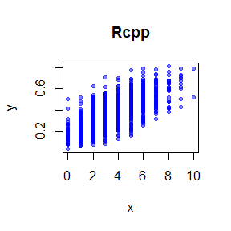

```r
library(RcppArmadillo)
library(SA24204177)
n<-10
a<-3
b<-5
N<-1000
out<-200
res_rcpp<-Gibbs(n,a,b,N,out)
plot(res_rcpp[,1],res_rcpp[,2],pch=20,col=rgb(0,0,1,0.5),xlab = "x",ylab = "y",main = "Rcpp")
```

## 2、用R实现

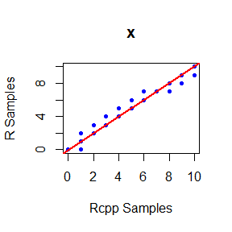

```r
set.seed(1234)
gibbs_r<-function(n,a,b,N,out){
  res_rx<- numeric(N)
  res_ry<- numeric(N)
  res_ry[1] <- 0.5
  for (i in 2:N) {
    res_rx[i] <- rbinom(1,n,res_ry[i-1])
    res_ry[i] <- rbeta(1,res_rx[i]+a,n-res_rx[i]+b)
  }
  cbind(res_rx,res_ry)
}
res_r<-gibbs_r(n,a,b,N,out)
#比较x
qqplot(res_rcpp[, 1],res_r[,1],
       main = "x",
       xlab = "Rcpp Samples", ylab = "R Samples", pch = 20, col = "blue")
abline(0, 1, col = "red", lwd = 2)
```

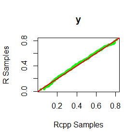

```r
#比较y
qqplot(res_rcpp[, 2],res_r[,2],
       main = "y",
       xlab = "Rcpp Samples", ylab = "R Samples", pch = 20, col = "green")
abline(0, 1, col = "red", lwd = 2)
```

## 3、比较运行时间

```r
library(microbenchmark)
ts<-microbenchmark(Rcpp=Gibbs(n,a,b,N,out),R=gibbs_r(n,a,b,N,out))
summary(ts)[,c(1,3,5,6)]
```

```
##   expr      lq  median     uq
## 1 Rcpp  343.60  358.25  373.3
## 2    R 3884.25 3977.35 4965.9
```

## 4、评论

根据结果可以看出，Rcpp函数所需运行时间显著小于R函数，因此Rcpp函数具有更好的性能。